# Agenda

- Entrance Ticket: [ET_0924](https://bart.instructure.com/courses/2110/quizzes/3196)
- Shifting $y=\sqrt{x}$
  - [slides_0924](https://chadworley.github.io/algtwo2026/u02/09_24/slides_0924.html)
  - [OCW_0924_A_shift_square_root](https://bart.instructure.com/courses/2110/quizzes/3199)
- Shifting $y=|x|$ and $y=x^2$ and $y=x^3$ and $y=\sqrt[3]{x}$
  - [OCW_0924_B_shift_parents](https://bart.instructure.com/courses/2110/quizzes/3200)

# The square-root function

- The [square-root](https://en.wikipedia.org/wiki/Square_root) function is typically indicated with a [radical symbol](https://en.wikipedia.org/wiki/Radical_symbol).
  $$\text{square-root}(x) ~=~
  \sqrt{x}$$
- Notice the [overline](https://en.wikipedia.org/wiki/Overline) indicates the [argument](https://en.wikipedia.org/wiki/Argument_of_a_function) of the function.
  $$\sqrt{\mathrm{argument}}$$
- The square-root function is an imperfect **[inverse](https://en.wikipedia.org/wiki/Inverse_function)** of the squaring function. For example…
  $$\sqrt{3^2}=3$$
  $$\sqrt{4^2}=4$$
  $$\sqrt{(-4)^2}\ne -4$$
- Here are some key input-output pairs:
  $$\sqrt{0}=0$$
  $$\sqrt{1}=1$$
  $$\sqrt{4}=2$$
  $$\sqrt{9}=3$$
  $$\sqrt{16}=4$$
  $$\sqrt{25}=5$$
- Practice: evaluate the expression.
  $$2\cdot \sqrt{\frac{10}{2}+11}+4$$

# The graph of $y=\sqrt{x}$

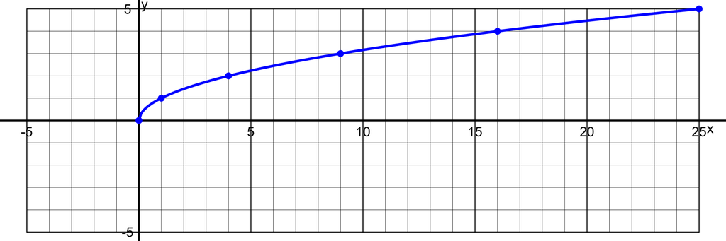

| $x$ | $y$ |
| --- | --- |
| 0 | 0 |
| 1 | 1 |
| 4 | 2 |
| 9 | 3 |
| 16 | 4 |
| 25 | 5 |

# Add a constant in the argument

Some solutions to $b=\sqrt{a}$ are shown below.

| $a$ | $b$ | equation |
| --- | --- | --- |
| 0 | 0 | $\sqrt{0}=0$ |
| 1 | 1 | $\sqrt{1}=1$ |
| 4 | 2 | $\sqrt{4}=2$ |
| 9 | 3 | $\sqrt{9}=3$ |
| 16 | 4 | $\sqrt{16}=4$ |
| 25 | 5 | $\sqrt{25}=5$ |

Find the corresponding solutions to $y=\sqrt{x+2}$.

| $x$ | $y$ |
| --- | --- |
| $\phantom{\cfrac{999}{999}}$ | $\phantom{\cfrac{999}{999}}$ |
| $\phantom{\cfrac{999}{999}}$ | $\phantom{\cfrac{999}{999}}$ |
| $\phantom{\cfrac{999}{999}}$ | $\phantom{\cfrac{999}{999}}$ |
| $\phantom{\cfrac{999}{999}}$ | $\phantom{\cfrac{999}{999}}$ |
| $\phantom{\cfrac{999}{999}}$ | $\phantom{\cfrac{999}{999}}$ |
| $\phantom{\cfrac{999}{999}}$ | $\phantom{\cfrac{999}{999}}$ |

# Graph of $y=\sqrt{x+2}$

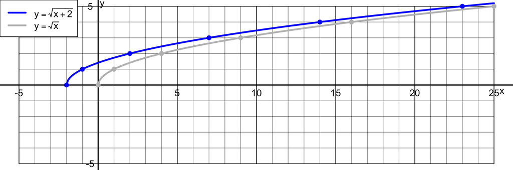

Adding 2 inside the argument shifted (translated) the curve 2 units to the **LEFT**.

# Add constant outside of function

Some solutions to $b=\sqrt{a}$ are shown below.

| $a$ | $b$ | equation |
| --- | --- | --- |
| 0 | 0 | $\sqrt{0}=0$ |
| 1 | 1 | $\sqrt{1}=1$ |
| 4 | 2 | $\sqrt{4}=2$ |
| 9 | 3 | $\sqrt{9}=3$ |
| 16 | 4 | $\sqrt{16}=4$ |
| 25 | 5 | $\sqrt{25}=5$ |

Find the corresponding solutions to $y=\sqrt{x}+2$.

| $x$ | $y$ |
| --- | --- |
| $\phantom{\cfrac{999}{999}}$ | $\phantom{\cfrac{999}{999}}$ |
| $\phantom{\cfrac{999}{999}}$ | $\phantom{\cfrac{999}{999}}$ |
| $\phantom{\cfrac{999}{999}}$ | $\phantom{\cfrac{999}{999}}$ |
| $\phantom{\cfrac{999}{999}}$ | $\phantom{\cfrac{999}{999}}$ |
| $\phantom{\cfrac{999}{999}}$ | $\phantom{\cfrac{999}{999}}$ |
| $\phantom{\cfrac{999}{999}}$ | $\phantom{\cfrac{999}{999}}$ |

# Graph of $y=\sqrt{x}+2$

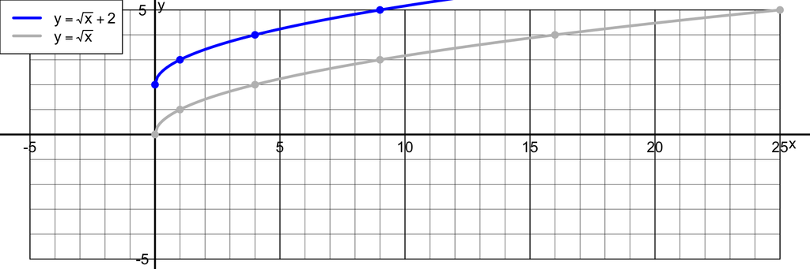

Adding 2 outside the argument shifted (translated) the curve 2 units **UP**.

# Subtract constant inside of function

Some solutions to $b=\sqrt{a}$ are shown below.

| $a$ | $b$ | equation |
| --- | --- | --- |
| 0 | 0 | $\sqrt{0}=0$ |
| 1 | 1 | $\sqrt{1}=1$ |
| 4 | 2 | $\sqrt{4}=2$ |
| 9 | 3 | $\sqrt{9}=3$ |
| 16 | 4 | $\sqrt{16}=4$ |
| 25 | 5 | $\sqrt{25}=5$ |

Find the corresponding solutions to $y=\sqrt{x-2}$.

| $x$ | $y$ |
| --- | --- |
| $\phantom{\cfrac{999}{999}}$ | $\phantom{\cfrac{999}{999}}$ |
| $\phantom{\cfrac{999}{999}}$ | $\phantom{\cfrac{999}{999}}$ |
| $\phantom{\cfrac{999}{999}}$ | $\phantom{\cfrac{999}{999}}$ |
| $\phantom{\cfrac{999}{999}}$ | $\phantom{\cfrac{999}{999}}$ |
| $\phantom{\cfrac{999}{999}}$ | $\phantom{\cfrac{999}{999}}$ |
| $\phantom{\cfrac{999}{999}}$ | $\phantom{\cfrac{999}{999}}$ |

# Graph of $y=\sqrt{x-2}$

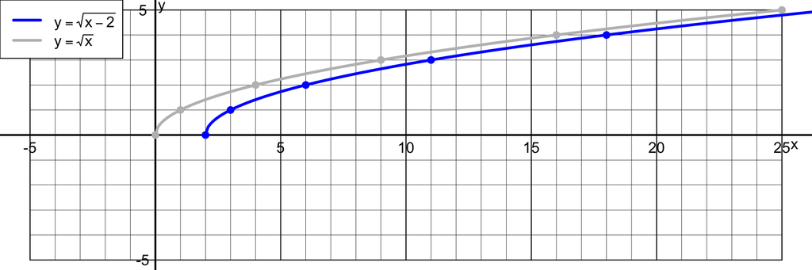

**Subtracting** 2 inside the argument shifted (translated) the curve 2 units **RIGHT**.

$$(a,b)~\to~(a+2,b)$$

The horizontal coordinate transformations are from the INVERSE of the argument.

Remember, we can set the argument equal to $a$.

$$a=x-2$$

And solve for $x$.

$$x=a+2$$

# Subtracting a constant outside the function

Some solutions to $b=\sqrt{a}$ are shown below.

| $a$ | $b$ | equation |
| --- | --- | --- |
| 0 | 0 | $\sqrt{0}=0$ |
| 1 | 1 | $\sqrt{1}=1$ |
| 4 | 2 | $\sqrt{4}=2$ |
| 9 | 3 | $\sqrt{9}=3$ |
| 16 | 4 | $\sqrt{16}=4$ |
| 25 | 5 | $\sqrt{25}=5$ |

Find the corresponding solutions to $y=\sqrt{x}-2$.

| $x$ | $y$ |
| --- | --- |
| $\phantom{\cfrac{999}{999}}$ | $\phantom{\cfrac{999}{999}}$ |
| $\phantom{\cfrac{999}{999}}$ | $\phantom{\cfrac{999}{999}}$ |
| $\phantom{\cfrac{999}{999}}$ | $\phantom{\cfrac{999}{999}}$ |
| $\phantom{\cfrac{999}{999}}$ | $\phantom{\cfrac{999}{999}}$ |
| $\phantom{\cfrac{999}{999}}$ | $\phantom{\cfrac{999}{999}}$ |
| $\phantom{\cfrac{999}{999}}$ | $\phantom{\cfrac{999}{999}}$ |

# Graph of $y=\sqrt{x}-2$

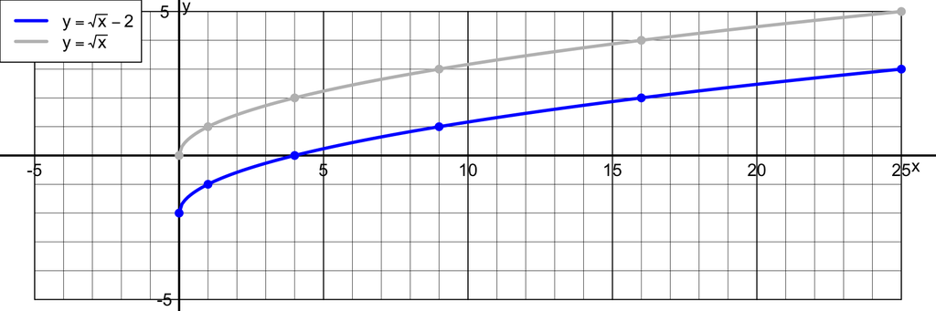

Subtracting 2 outside the function resulted is a shift **DOWN** by 2 units.

$$(a,b)~\to~(a,b-2)$$

Notice, we just replace the whole square-root function (and its argument) with $b$.

# Adding or Subtracting Inside and Out

Use these facts:
$$\sqrt{0}=0$$
$$\sqrt{1}=1$$
$$\sqrt{4}=2$$
$$\sqrt{9}=3$$
$$\sqrt{16}=4$$
$$\sqrt{25}=5$$

To find corresponding solutions to the equation below:
$$y=\sqrt{x-6}-4$$

# Some solutions to $y=\sqrt{x-6}-4$

| square-root fact | $~~~x~~~$ | $\sqrt{x-6}-4$ | $~~~y~~~$ |
| --- | --- | --- | --- |
| $\sqrt{0}=0$ | $6$ | $\sqrt{6-6}-4$ | $-4$ |
| $\sqrt{1}=1$ | $7$ | $\sqrt{7-6}-4$ | $-3$ |
| $\sqrt{4}=2$ | $10$ | $\sqrt{10-6}-4$ | $-2$ |
| $\sqrt{9}=3$ | $15$ | $\sqrt{15-6}-4$ | $-1$ |
| $\sqrt{16}=4$ | $22$ | $\sqrt{22-6}-4$ | $0$ |
| $\sqrt{25}=5$ | $31$ | $\sqrt{31-6}-4$ | $1$ |

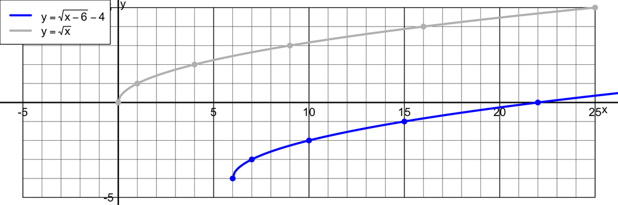

The curve shifted 6 units right and 4 units down.

# Other examples of shifted parent functions

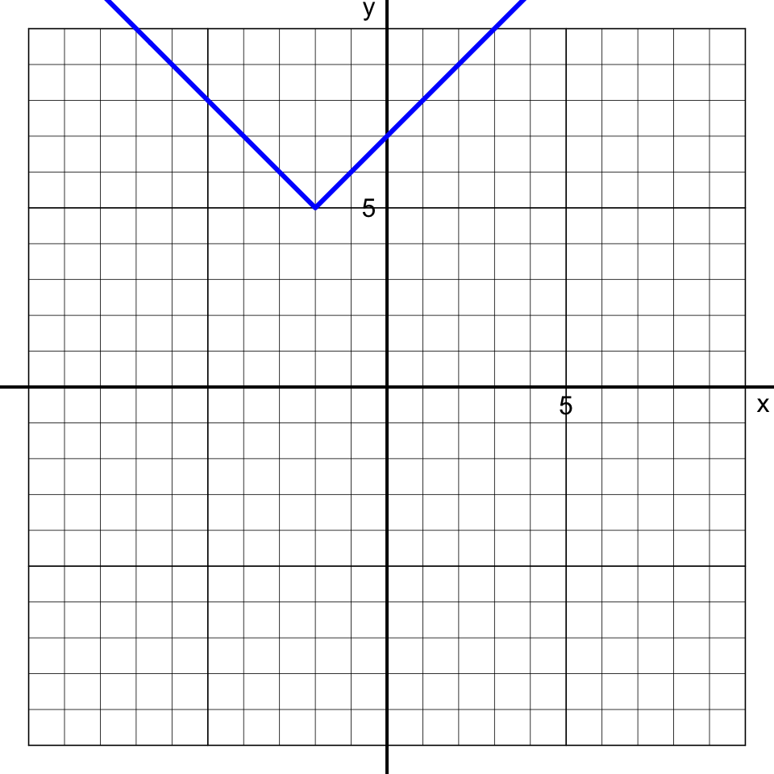

$$y=|x+2|+5$$

# Other examples of shifted parent functions

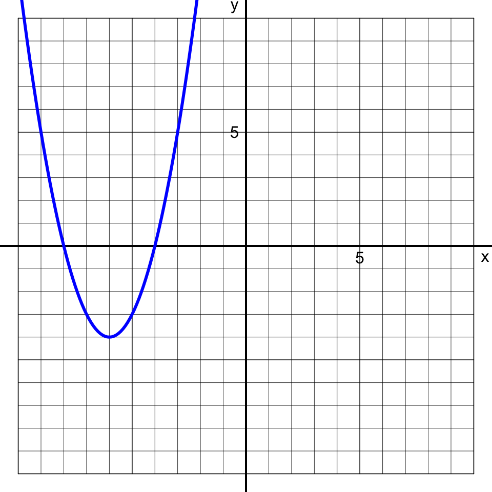

$$y=(x+6)^2-4$$

# Other examples of shifted parent functions

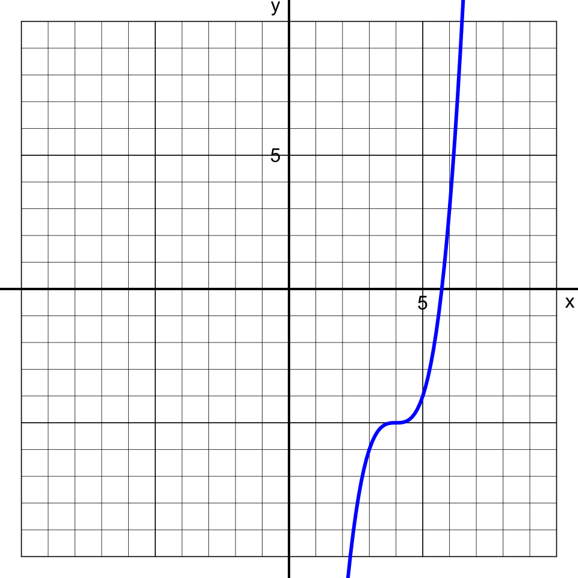

$$y=(x-4)^3-5$$

# Other examples of shifted parent functions

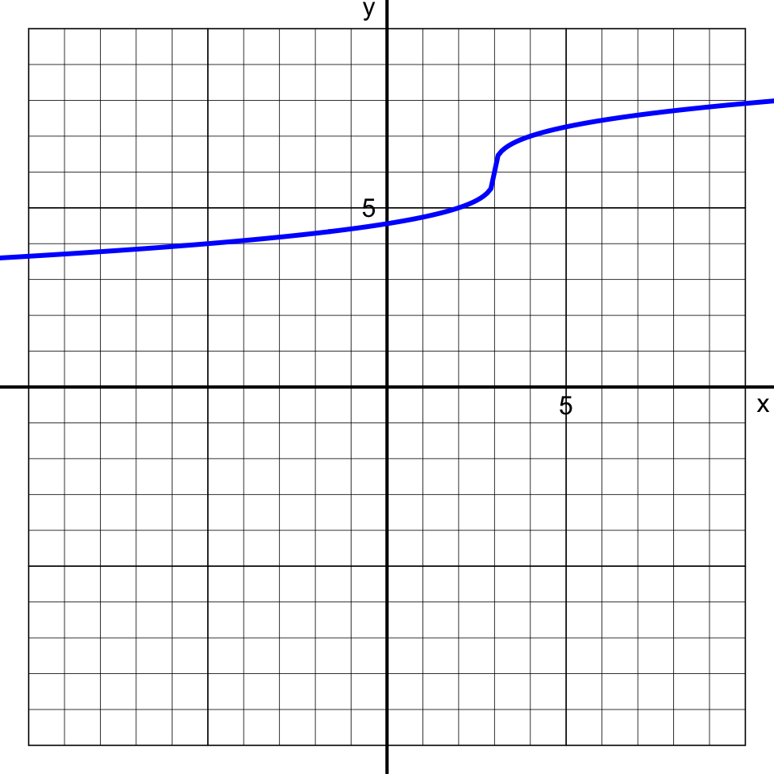

$$y=\sqrt[3]{x-3}+6$$